# BST260_Final_Project

Wenyu Jin

2021/11/30

### Machine Learning I (Binary Classification)

#### Mode (binary variable) as outcome

```r
library(splitstackshape)
library(caret)
library(e1071)
library(MASS)
library(pROC)
library(rpart)
library(randomForest)
library(knitr)
library(dplyr)
library(ggplot2)
library(gridExtra)
```

```r
data_clean <- readRDS("music_genre_clean.rds")
```

##### Exploratory analysis (EDA)

```r
# Frequency of mode
count(data_clean, mode)
```

```
## # A tibble: 2 × 2
##   mode      n
##   <fct> <int>
## 1 Major 25959
## 2 Minor 14601
```

```r
# Contingency table for mode and music genre
tab1 <- xtabs(~ mode + music_genre, data = data_clean)
tab1
```

```
##        music_genre
## mode    Alternative Anime Blues Classical Country Electronic Hip-Hop Jazz  Rap
##   Major        2551  2524  2878      2683    3524       2147    2272 2136 2227
##   Minor        1500  1540  1168      1353     525       1885    1805 1928 1815
##        music_genre
## mode    Rock
##   Major 3017
##   Minor 1082
```

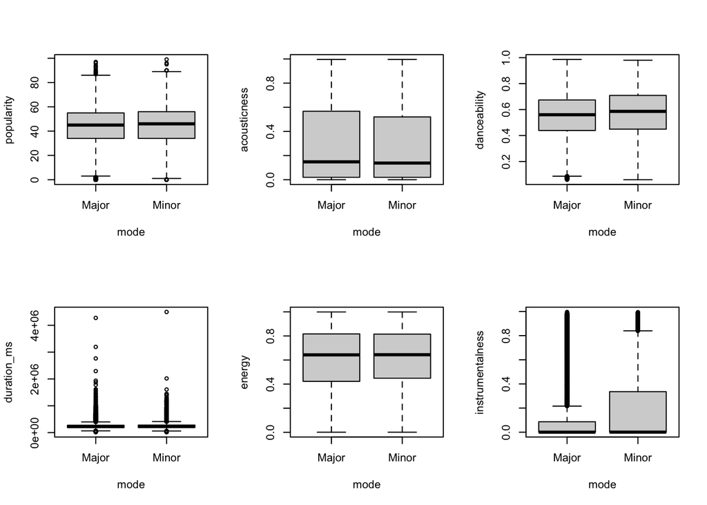

```r
# Box plots for continuous predictors
par(mfrow=c(2,3))
boxplot(popularity ~ mode, data = data_clean)
boxplot(acousticness ~ mode, data = data_clean)
boxplot(danceability ~ mode, data = data_clean)
boxplot(duration_ms ~ mode, data = data_clean)
boxplot(energy ~ mode, data = data_clean)
boxplot(instrumentalness ~ mode, data = data_clean)
```

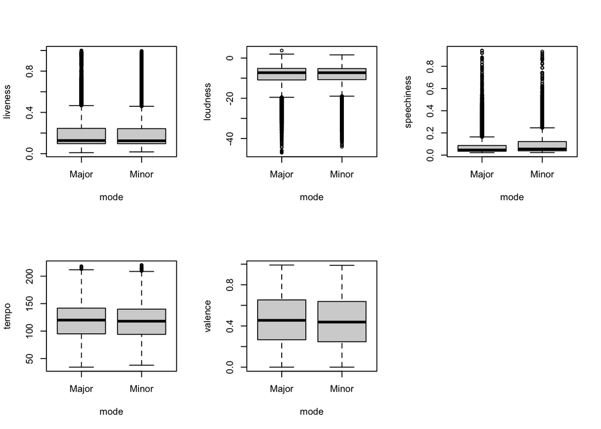

```r
boxplot(liveness ~ mode, data = data_clean)
boxplot(loudness ~ mode, data = data_clean)
boxplot(speechiness ~ mode, data = data_clean)
boxplot(tempo ~ mode, data = data_clean)
boxplot(valence ~ mode, data = data_clean)
```

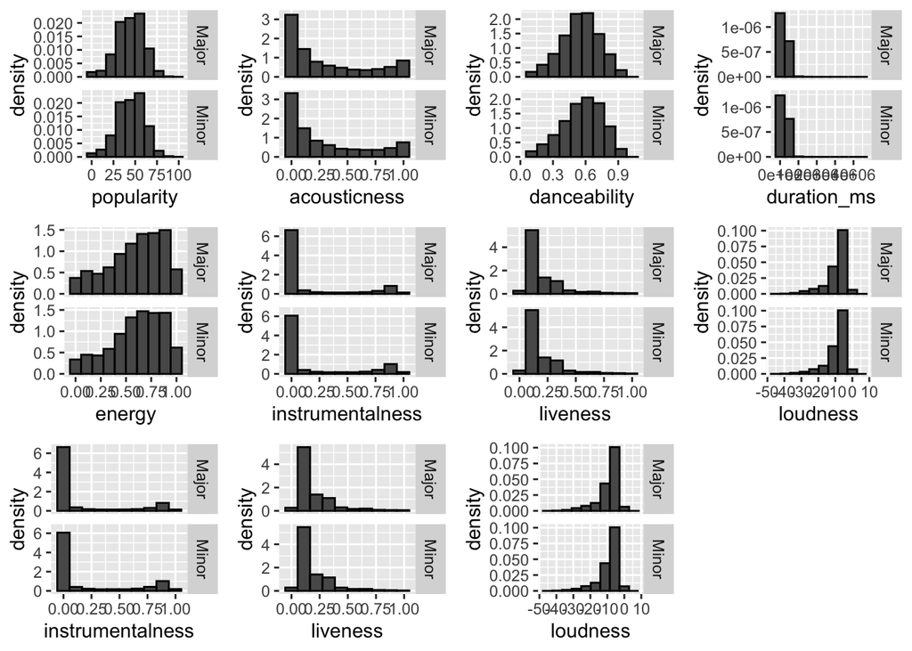

```r
# Histogram for continuous predictors
h1 <- data_clean %>%
  ggplot(aes(popularity, ..density..)) +
  geom_histogram(bins=10, color="black") +
  facet_grid(mode~.)
h2 <- data_clean %>%
  ggplot(aes(acousticness, ..density..)) +
  geom_histogram(bins=10, color="black") +
  facet_grid(mode~.)
h3 <- data_clean %>%
  ggplot(aes(danceability, ..density..)) +
  geom_histogram(bins=10, color="black") +
  facet_grid(mode~.)
h4 <- data_clean %>%
  ggplot(aes(duration_ms, ..density..)) +
  geom_histogram(bins=10, color="black") +
  facet_grid(mode~.)
h5 <- data_clean %>%
  ggplot(aes(energy, ..density..)) +
  geom_histogram(bins=10, color="black") +
  facet_grid(mode~.)
h6 <- data_clean %>%
  ggplot(aes(instrumentalness, ..density..)) +
  geom_histogram(bins=10, color="black") +
  facet_grid(mode~.)
h7 <- data_clean %>%
  ggplot(aes(liveness, ..density..)) +
  geom_histogram(bins=10, color="black") +
  facet_grid(mode~.)
h8 <- data_clean %>%
  ggplot(aes(loudness, ..density..)) +
  geom_histogram(bins=10, color="black") +
  facet_grid(mode~.)
h9 <- data_clean %>%
  ggplot(aes(instrumentalness, ..density..)) +
  geom_histogram(bins=10, color="black") +
  facet_grid(mode~.)
h10 <- data_clean %>%
  ggplot(aes(liveness, ..density..)) +
  geom_histogram(bins=10, color="black") +
  facet_grid(mode~.)
h11 <- data_clean %>%
  ggplot(aes(loudness, ..density..)) +
  geom_histogram(bins=10, color="black") +
  facet_grid(mode~.)

grid.arrange(h1,h2,h3,h4,h5,h6,h7,h8,h9,h10,h11, ncol = 4)
```

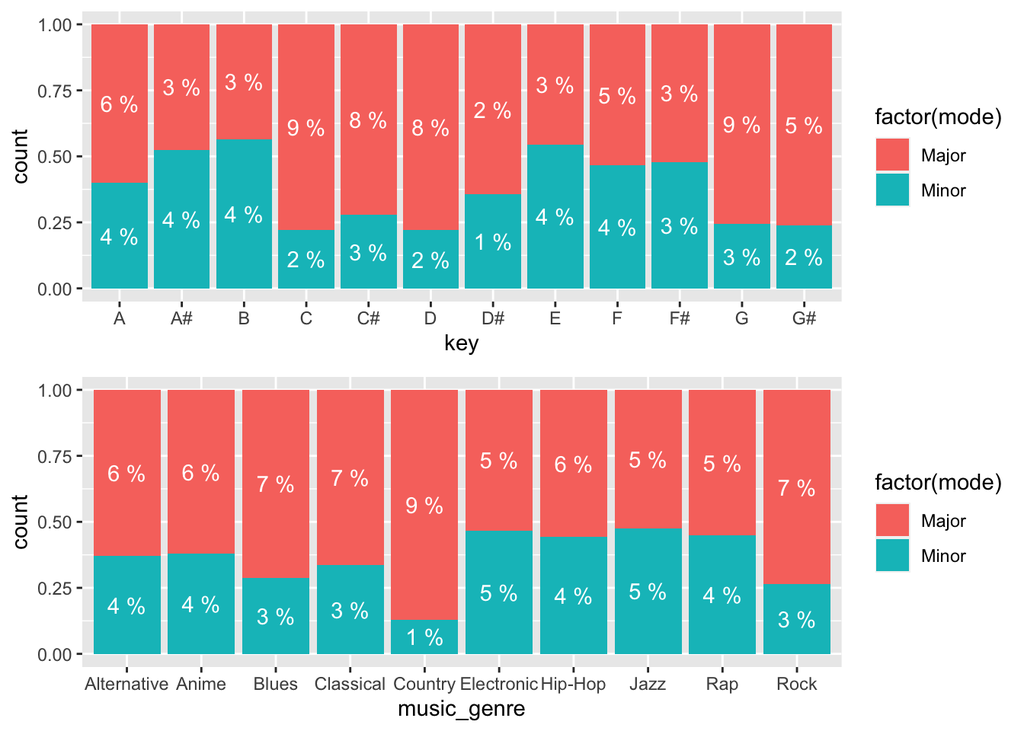

```r
# Stacked bar charts for categorical predictors
p1 <- data_clean %>% ggplot(aes(x=key,fill=factor(mode))) +
  geom_bar(position = "fill") +
  stat_count(geom = "text",
             aes(label = paste(round((..count..)/sum(..count..)*100), "%")),
             position=position_fill(vjust=0.5), colour="white")
p2 <- data_clean %>% ggplot(aes(x=music_genre,fill=factor(mode))) +
  geom_bar(position = "fill") +
  stat_count(geom = "text",
             aes(label = paste(round((..count..)/sum(..count..)*100), "%")),
             position=position_fill(vjust=0.5), colour="white")
grid.arrange(p1,p2,ncol=1)
```

According to EDA, four continuous variables (acousticness, danceability, instrumentalness, speechiness) and two categorical variables (key and music genre) visually display different distributions at two types of modes. So the six variables will be selected as the predictors for the following binary classification.

##### Prepare the data for binary classification

```r
# Set level for mode (Minor=1, Major=0)
levels(data_clean$mode) <- c(0,1)
```

A 70% training, 30% test set split is used. Since there is an imbalance in the outcome groups (25959/40560 = 64% songs with major modes and 14601/40560 = 36% with minor modes), we take this into account during data spliting and use stratified function to split data the same percent of songs from each class (major/minor).

```r
# Create training and test sets
set.seed(1)

x <- stratified(data_clean, "mode", 0.7, keep.rownames = TRUE)
train_set <- x %>% dplyr::select(-rn)
train_index <- as.numeric(x$rn)
test_set <- data_clean[-train_index,]

dim(train_set)
```

```
## [1] 28392    14
```

```r
dim(test_set)
```

```
## [1] 12168    14
```

##### Logistic regression

```r
# Fit a logistic regression model
glm_fit <- glm(mode ~ acousticness + danceability + instrumentalness + speechiness + key + music_genre, data= train_set, family = "binomial")
# Prediction for the test set
p_hat_logit <- predict(glm_fit, newdata = test_set, type="response")
# Convert the probabilities to predicted response labels
y_hat_logit <- ifelse(p_hat_logit > 0.5, 1, 0)
cm_logit <- confusionMatrix(data = as.factor(y_hat_logit), reference = as.factor(test_set$mode))
cm_logit
```

```
## Confusion Matrix and Statistics
##
##           Reference
## Prediction    0    1
##          0 6641 2556
##          1 1147 1824
##
##                Accuracy : 0.6957
##                  95% CI : (0.6874, 0.7038)
##     No Information Rate : 0.64
##     P-Value [Acc > NIR] : < 2.2e-16
##
##                   Kappa : 0.2895
##
##  Mcnemar's Test P-Value : < 2.2e-16
##
##             Sensitivity : 0.8527
##             Specificity : 0.4164
##          Pos Pred Value : 0.7221
##          Neg Pred Value : 0.6139
##              Prevalence : 0.6400
##          Detection Rate : 0.5458
##    Detection Prevalence : 0.7558
##       Balanced Accuracy : 0.6346
##
##        'Positive' Class : 0
##
```

##### Naive Bayes

```r
# Fit a Naive Bayes model
nb_fit <- naiveBayes(mode ~ acousticness + danceability + instrumentalness + speechiness + key + music_genre, data=train_set)
# Prediction for the test set
p_hat_nb <- predict(nb_fit, test_set, type = "raw")[,2]
# Convert the probabilities to predicted response labels
y_hat_nb <- predict(nb_fit, test_set)
# Confusion matrix
cm_nb <- confusionMatrix(data = as.factor(y_hat_nb), reference = as.factor(test_set$mode))
cm_nb
```

```
## Confusion Matrix and Statistics
##
##           Reference
## Prediction    0    1
##          0 6527 2658
##          1 1261 1722
##
##                Accuracy : 0.6779
##                  95% CI : (0.6695, 0.6862)
##     No Information Rate : 0.64
##     P-Value [Acc > NIR] : < 2.2e-16
##
##                   Kappa : 0.2486
##
##  Mcnemar's Test P-Value : < 2.2e-16
##
##             Sensitivity : 0.8381
##             Specificity : 0.3932
##          Pos Pred Value : 0.7106
##          Neg Pred Value : 0.5773
##              Prevalence : 0.6400
##          Detection Rate : 0.5364
##    Detection Prevalence : 0.7548
##       Balanced Accuracy : 0.6156
##
##        'Positive' Class : 0
##
```

##### kNN

```r
# Fit a k-nearest neighbors model
knn_fit <- knn3(mode ~ acousticness + danceability + instrumentalness + speechiness + key + music_genre, data=train_set, k=7)
# Prediction for the test set
f_hat <- predict(knn_fit, newdata = test_set)[,2]
# Confusion matrix
f_tab <- table(pred=round(f_hat), truth=test_set$mode)
cm_knn <- confusionMatrix(f_tab)
cm_knn
```

```
## Confusion Matrix and Statistics
##
##     truth
## pred    0    1
##    0 6315 2386
##    1 1473 1994
##
##                Accuracy : 0.6829
##                  95% CI : (0.6745, 0.6911)
##     No Information Rate : 0.64
##     P-Value [Acc > NIR] : < 2.2e-16
##
##                   Kappa : 0.2788
##
##  Mcnemar's Test P-Value : < 2.2e-16
##
##             Sensitivity : 0.8109
##             Specificity : 0.4553
##          Pos Pred Value : 0.7258
##          Neg Pred Value : 0.5751
##              Prevalence : 0.6400
##          Detection Rate : 0.5190
##    Detection Prevalence : 0.7151
##       Balanced Accuracy : 0.6331
##
##        'Positive' Class : 0
##
```

##### LDA

```r
# Fit an LDA model
set.seed(1)
lda_fit <- lda(mode ~ acousticness + danceability + instrumentalness + speechiness + key + music_genre, data=train_set)
# Prediction for the test set
p_hat_lda <- predict(lda_fit, newdata = test_set)$posterior[,2]
# Convert the probabilities to predicted response labels
y_hat_lda <- ifelse(p_hat_lda > 0.5, 1, 0)
# Confusion matrix
cm_lda <- confusionMatrix(data = as.factor(y_hat_lda), reference = as.factor(test_set$mode))
cm_lda
```

```
## Confusion Matrix and Statistics
##
##           Reference
## Prediction    0    1
##          0 6638 2566
##          1 1150 1814
##
##                Accuracy : 0.6946
##                  95% CI : (0.6863, 0.7028)
##     No Information Rate : 0.64
##     P-Value [Acc > NIR] : < 2.2e-16
##
##                   Kappa : 0.2868
##
##  Mcnemar's Test P-Value : < 2.2e-16
##
##             Sensitivity : 0.8523
##             Specificity : 0.4142
##          Pos Pred Value : 0.7212
##          Neg Pred Value : 0.6120
##              Prevalence : 0.6400
##          Detection Rate : 0.5455
##    Detection Prevalence : 0.7564
##       Balanced Accuracy : 0.6332
##
##        'Positive' Class : 0
##
```

##### QDA

```r
# Fit a QDA model
set.seed(1)
qda_fit <- qda(mode ~ acousticness + danceability + instrumentalness + speechiness + key + music_genre, data=train_set)
# Prediction for the test set
p_hat_qda <- predict(qda_fit, newdata = test_set)$posterior[,2]
# Convert the probabilities to predicted response labels
y_hat_qda <- ifelse(p_hat_qda > 0.5, 1, 0)
# Confusion matrix
cm_qda <- confusionMatrix(data = as.factor(y_hat_qda), reference = as.factor(test_set$mode))
cm_qda
```

```
## Confusion Matrix and Statistics
##
##           Reference
## Prediction    0    1
##          0 5689 1771
##          1 2099 2609
##
##                Accuracy : 0.682
##                  95% CI : (0.6736, 0.6902)
##     No Information Rate : 0.64
##     P-Value [Acc > NIR] : < 2.2e-16
##
##                   Kappa : 0.3209
##
##  Mcnemar's Test P-Value : 1.469e-07
##
##             Sensitivity : 0.7305
##             Specificity : 0.5957
##          Pos Pred Value : 0.7626
##          Neg Pred Value : 0.5542
##              Prevalence : 0.6400
##          Detection Rate : 0.4675
##    Detection Prevalence : 0.6131
##       Balanced Accuracy : 0.6631
##
##        'Positive' Class : 0
##
```

##### Decision trees

```r
# Fit a decision tree model
set.seed(1)
rpart_fit <- rpart(mode ~ acousticness + danceability + instrumentalness + speechiness + key + music_genre, data=train_set)
# Prediction for the test set
p_hat_rpart <- predict(rpart_fit, newdata = test_set)[,2]
# Convert the probabilities to predicted response labels
y_hat_rpart <- ifelse(p_hat_rpart > 0.5, 1, 0)
# Confusion matrix
cm_rpart <- confusionMatrix(data = as.factor(y_hat_rpart), reference = as.factor(test_set$mode))
cm_rpart
```

```
## Confusion Matrix and Statistics
##
##           Reference
## Prediction    0    1
##          0 6382 2363
##          1 1406 2017
##
##                Accuracy : 0.6903
##                  95% CI : (0.682, 0.6985)
##     No Information Rate : 0.64
##     P-Value [Acc > NIR] : < 2.2e-16
##
##                   Kappa : 0.294
##
##  Mcnemar's Test P-Value : < 2.2e-16
##
##             Sensitivity : 0.8195
##             Specificity : 0.4605
##          Pos Pred Value : 0.7298
##          Neg Pred Value : 0.5892
##              Prevalence : 0.6400
##          Detection Rate : 0.5245
##    Detection Prevalence : 0.7187
##       Balanced Accuracy : 0.6400
##
##        'Positive' Class : 0
##
```

##### Random forest

```r
# Fit a random forest model
set.seed(1)
rf_fit <- randomForest(mode ~ acousticness + danceability + instrumentalness + speechiness + key + music_genre, data=train_set)
# Prediction for the test set
p_hat_rf <- predict(rf_fit, newdata = test_set, type = "prob")[,2]
# Convert the probabilities to predicted response labels
y_hat_rf <- ifelse(p_hat_rf > 0.5, 1, 0)
# Confusion matrix
cm_rf <- confusionMatrix(data = as.factor(y_hat_rf), reference = as.factor(test_set$mode))
cm_rf
```

```
## Confusion Matrix and Statistics
##
##           Reference
## Prediction    0    1
##          0 6681 2336
##          1 1107 2044
##
##                Accuracy : 0.717
##                  95% CI : (0.7089, 0.725)
##     No Information Rate : 0.64
##     P-Value [Acc > NIR] : < 2.2e-16
##
##                   Kappa : 0.3458
##
##  Mcnemar's Test P-Value : < 2.2e-16
##
##             Sensitivity : 0.8579
##             Specificity : 0.4667
##          Pos Pred Value : 0.7409
##          Neg Pred Value : 0.6487
##              Prevalence : 0.6400
##          Detection Rate : 0.5491
##    Detection Prevalence : 0.7410
##       Balanced Accuracy : 0.6623
##
##        'Positive' Class : 0
##
```

```r
# Variable importance table
variable_importance <- importance(rf_fit)
tmp <- tibble(feature = rownames(variable_importance),
                  Gini = variable_importance[,1]) %>%
                  arrange(desc(Gini))
kable(tmp)
```

| feature | Gini |
| --- | --- |
| speechiness | 2614.770 |
| acousticness | 2570.598 |
| danceability | 2519.674 |
| instrumentalness | 1983.245 |
| key | 1963.138 |
| music_genre | 1132.148 |

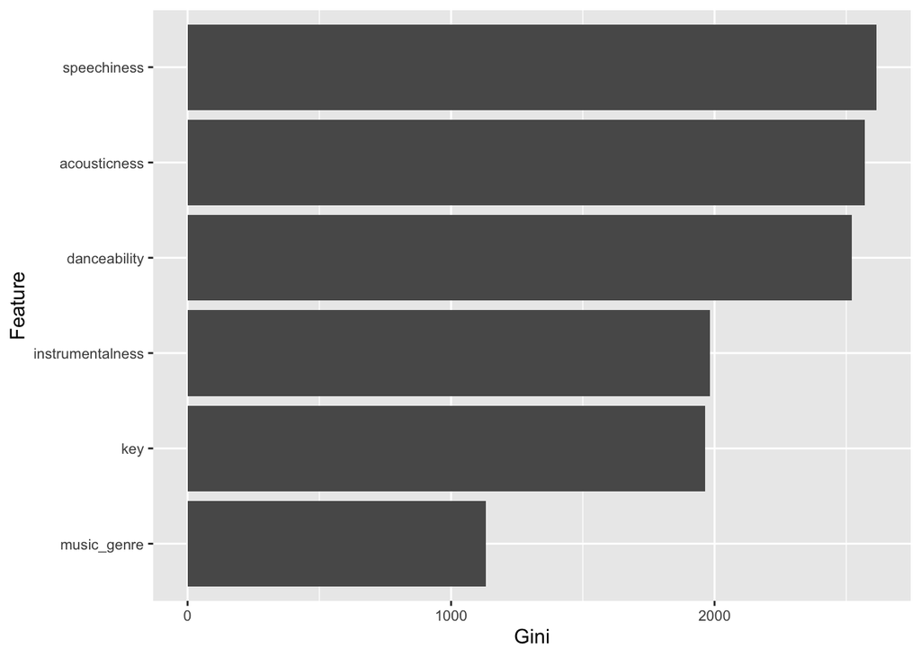

```r
# Bar plot of variable importance
tmp %>% filter(Gini > 200) %>%
        ggplot(aes(x=reorder(feature, Gini), y=Gini)) +
        geom_bar(stat='identity') +
        coord_flip() + xlab("Feature") +
        theme(axis.text=element_text(size=8))
```

Among the six variables, speechiness, acousticness and danceability have Gini indices above 2000 and therefore have relatively higher variable importance compared to the other three variables. So random forest with only speechiness, acousticness and danceability will be fitted to explore whether fewer variables will give similar or better performance.

```r
# Fit another random forest model
set.seed(1)
rf_fit2 <- randomForest(mode ~ acousticness + danceability + speechiness, data=train_set)
# Prediction for the test set
p_hat_rf2 <- predict(rf_fit2, newdata = test_set, type = "prob")[,2]
# Convert the probabilities to predicted response labels
y_hat_rf2 <- ifelse(p_hat_rf2 > 0.5, 1, 0)
# Confusion matrix
cm_rf2 <- confusionMatrix(data = as.factor(y_hat_rf2), reference = as.factor(test_set$mode))
cm_rf2
```

```
## Confusion Matrix and Statistics
##
##           Reference
## Prediction    0    1
##          0 6618 3138
##          1 1170 1242
##
##                Accuracy : 0.646
##                  95% CI : (0.6374, 0.6545)
##     No Information Rate : 0.64
##     P-Value [Acc > NIR] : 0.08832
##
##                   Kappa : 0.1479
##
##  Mcnemar's Test P-Value : < 2e-16
##
##             Sensitivity : 0.8498
##             Specificity : 0.2836
##          Pos Pred Value : 0.6784
##          Neg Pred Value : 0.5149
##              Prevalence : 0.6400
##          Detection Rate : 0.5439
##    Detection Prevalence : 0.8018
##       Balanced Accuracy : 0.5667
##
##        'Positive' Class : 0
##
```

After including the 3 variables with Gini index above 2000, the overall accuracy decreases from 0.717 to 0.646. Thus, we will still stick with the machine learning models containing the 6 variables.

##### Model comparison

###### Overall accuracy, specificity, and sensitivity

```r
cm_logit$byClass[1:2]
```

```
## Sensitivity Specificity
##   0.8527221   0.4164384
```

```r
tab2 <- matrix(c(cm_logit$overall[1],cm_logit$byClass[1:2],
                 cm_nb$overall[1],cm_nb$byClass[1:2],
                 cm_knn$overall[1],cm_knn$byClass[1:2],
                 cm_lda$overall[1],cm_lda$byClass[1:2],
                 cm_qda$overall[1],cm_qda$byClass[1:2],
                 cm_rpart$overall[1],cm_rpart$byClass[1:2],
                 cm_rf$overall[1],cm_rf$byClass[1:2]), ncol=3, byrow = TRUE)
colnames(tab2) <- c("Accuracy","Sensitivity","Specificity")
rownames(tab2) <- c("Logistic Regression", "Naive Bayes", "kNN", "LDA", "QDA", "Decision Tree", "Random Forest")
tab2
```

```
##                      Accuracy Sensitivity Specificity
## Logistic Regression 0.6956772   0.8527221   0.4164384
## Naive Bayes         0.6779257   0.8380842   0.3931507
## kNN                 0.6828567   0.8108629   0.4552511
## LDA                 0.6946088   0.8523369   0.4141553
## QDA                 0.6819527   0.7304828   0.5956621
## Decision Tree       0.6902531   0.8194658   0.4605023
## Random Forest       0.7170447   0.8578582   0.4666667
```

###### ROC curves

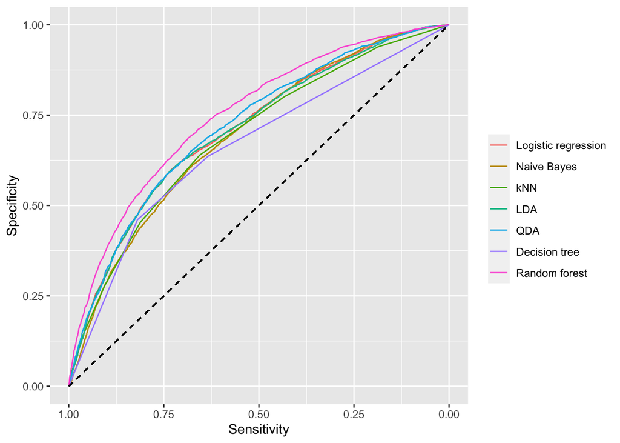

```r
## Logistic regression
roc_glm <- roc(as.factor(test_set$mode),p_hat_logit)
## Naive Bayes
roc_nb <- roc(as.factor(test_set$mode), p_hat_nb)
## kNN
roc_knn <- roc(as.factor(test_set$mode), f_hat)
## LDA
roc_lda <- roc(as.factor(test_set$mode),p_hat_lda)
## QDA
roc_qda <- roc(as.factor(test_set$mode), p_hat_qda)
## Decision tree
roc_rpart <- roc(as.factor(test_set$mode), p_hat_rpart)
## Random forest
roc_rf <- roc(as.factor(test_set$mode), p_hat_rf)
# Graph with 7 ROC curves for each model
ggroc(list("Logistic regression" = roc_glm, "Naive Bayes" = roc_nb, "kNN" = roc_knn, "LDA" = roc_lda, "QDA" = roc_qda, "Decision tree" = roc_rpart, "Random forest" = roc_rf)) +
  theme(legend.title = element_blank()) +
  geom_segment(aes(x = 1, xend = 0, y = 0, yend = 1), color = "black", linetype = "dashed") +
  xlab("Sensitivity") +
  ylab("Specificity")
```

###### AUC values

```r
auc(roc_glm)
```

```
## Area under the curve: 0.7095
```

```r
auc(roc_nb)
```

```
## Area under the curve: 0.6944
```

```r
auc(roc_knn)
```

```
## Area under the curve: 0.6902
```

```r
auc(roc_lda)
```

```
## Area under the curve: 0.708
```

```r
auc(roc_qda)
```

```
## Area under the curve: 0.7181
```

```r
auc(roc_rpart)
```

```
## Area under the curve: 0.6619
```

```r
auc(roc_rf)
```

```
## Area under the curve: 0.7496
```

Among the 7 machine learning models, random forest has the highest overall accuracy (0.717) and AUC value (0.7496) ; and largest area under the ROC curve can be observed under the random forest model. Hence, the random forest model will be chosen as the best model to predict the mode of a song.